# project : No Show Appointments

- Introduction
- Data Wrangling
- Exploratory Data Analysis
- Conclusions

## Introduction

### Describing :

> - This dataset collects information from 100k medical appointments in Brazil and is focused on the question of whether or not patients show up for their appointment. A number of characteristics about the patient are included in each row.

● ‘ScheduledDay’ tells us on what day the patient set up their appointment.  
● ‘Neighborhood’ indicates the location of the hospital.  
● ‘Scholarship’ indicates whether or not the patient is enrolled in Brasilian welfare program "Bolsa Família".  
● ‘No_show’ it says ‘No’ if the patient showed up to their appointment, and ‘Yes’ if they did not show up.

### Questions we are trying to answer :

> - what is the overall appointment show-up vs. no show-up rate
> - what are the most feature that matter the most of ('Age', 'being alcoholic','Having an SMS', 'Gender', 'Scholarship'), to make the patient make it to his appiontment?

### Research Questiones in Dataset :-

R Q 1 : How many showed vs not_showed and what relation ?

R Q 3 : Does the scholarship affect attendance?

R Q 4 : Does 'Diabetes' affect attendance?

R Q 5 : Does "Hypertension" affect attendance?

R Q 6 : Does Does 'alcoholism' affect attendance??

R Q 7 : Does 'age' affect attendance?

R Q 8 : Are there anomalies in age, what is the average age of patients ?

R Q 9 : Which hospitals have the highest attendance rate and which are the least?

R Q 10 : Does 'Neighbourhood' affect attendance?

R Q 11 : Does 'Handicap' affect attendance?

R Q 12 : Does 'SMS_received' affect attendance?

### importing the libraries that we gonna use in our investigation

```python
#import Libraries we neaded
import pandas as pd
import numpy as np
import matplotlib.pyplot as plt
import seaborn as sns

#rememper to include a "magicword" so that your visualizations are plotting
%matplotlib inline
```

## Data Wrangling

> checking for cleanliness, and then trim and clean the dataset for analysis.

### General Properties :

```python
# Load the data in Framework by Pandas.
df = pd.read_csv('noshowappointments.csv')
```

```python
# num of columns and rows
df.shape
```

```
(110527, 14)
```

```python
# overview on colomns types data in file
df.info()
```

```
<class 'pandas.core.frame.DataFrame'>
RangeIndex: 110527 entries, 0 to 110526
Data columns (total 14 columns):
 #   Column          Non-Null Count   Dtype
---  ------          --------------   -----
 0   PatientId       110527 non-null  float64
 1   AppointmentID   110527 non-null  int64
 2   Gender          110527 non-null  object
 3   ScheduledDay    110527 non-null  object
 4   AppointmentDay  110527 non-null  object
 5   Age             110527 non-null  int64
 6   Neighbourhood   110527 non-null  object
 7   Scholarship     110527 non-null  int64
 8   Hipertension    110527 non-null  int64
 9   Diabetes        110527 non-null  int64
 10  Alcoholism      110527 non-null  int64
 11  Handcap         110527 non-null  int64
 12  SMS_received    110527 non-null  int64
 13  No-show         110527 non-null  object
dtypes: float64(1), int64(8), object(5)
memory usage: 11.8+ MB
```

no missing data

```python
# to Know some statistical properties such as mean, variance, skew, upper and lower value
df.describe()
```

|  | PatientId | AppointmentID | Age | Scholarship | Hipertension | Diabetes | Alcoholism | Handcap | SMS_received |
| --- | --- | --- | --- | --- | --- | --- | --- | --- | --- |
| count | 1.105270e+05 | 1.105270e+05 | 110527.000000 | 110527.000000 | 110527.000000 | 110527.000000 | 110527.000000 | 110527.000000 | 110527.000000 |
| mean | 1.474963e+14 | 5.675305e+06 | 37.088874 | 0.098266 | 0.197246 | 0.071865 | 0.030400 | 0.022248 | 0.321026 |
| std | 2.560949e+14 | 7.129575e+04 | 23.110205 | 0.297675 | 0.397921 | 0.258265 | 0.171686 | 0.161543 | 0.466873 |
| min | 3.921784e+04 | 5.030230e+06 | -1.000000 | 0.000000 | 0.000000 | 0.000000 | 0.000000 | 0.000000 | 0.000000 |
| 25% | 4.172614e+12 | 5.640286e+06 | 18.000000 | 0.000000 | 0.000000 | 0.000000 | 0.000000 | 0.000000 | 0.000000 |
| 50% | 3.173184e+13 | 5.680573e+06 | 37.000000 | 0.000000 | 0.000000 | 0.000000 | 0.000000 | 0.000000 | 0.000000 |
| 75% | 9.439172e+13 | 5.725524e+06 | 55.000000 | 0.000000 | 0.000000 | 0.000000 | 0.000000 | 0.000000 | 1.000000 |
| max | 9.999816e+14 | 5.790484e+06 | 115.000000 | 1.000000 | 1.000000 | 1.000000 | 1.000000 | 4.000000 | 1.000000 |

##### Looking for Data that need to be cleaned

```python
# are we can know is there null values from [info()] above , let us Try and sure..
pd.isna(df).sum()
```

```
PatientId         0
AppointmentID     0
Gender            0
ScheduledDay      0
AppointmentDay    0
Age               0
Neighbourhood     0
Scholarship       0
Hipertension      0
Diabetes          0
Alcoholism        0
Handcap           0
SMS_received      0
No-show           0
dtype: int64
```

- as we can see there is no null values too

```python
# check if there is a dublicates in the data
print("Num of dublicated : ", + sum(df.duplicated()))

#check if there is an age with minus or equle 0 value
df[df["Age"] <= 0]
```

```
Num of dublicated :  0
```

|  | PatientId | AppointmentID | Gender | ScheduledDay | AppointmentDay | Age | Neighbourhood | Scholarship | Hipertension | Diabetes | Alcoholism | Handcap | SMS_received | No-show |
| --- | --- | --- | --- | --- | --- | --- | --- | --- | --- | --- | --- | --- | --- | --- |
| 59 | 7.184428e+13 | 5638545 | F | 2016-04-29T08:08:43Z | 2016-04-29T00:00:00Z | 0 | CONQUISTA | 0 | 0 | 0 | 0 | 0 | 0 | No |
| 63 | 2.366233e+14 | 5628286 | M | 2016-04-27T10:46:12Z | 2016-04-29T00:00:00Z | 0 | SÃO BENEDITO | 0 | 0 | 0 | 0 | 0 | 0 | No |
| 64 | 1.885174e+14 | 5616082 | M | 2016-04-25T13:28:21Z | 2016-04-29T00:00:00Z | 0 | ILHA DAS CAIEIRAS | 0 | 0 | 0 | 0 | 0 | 1 | No |
| 65 | 2.718818e+14 | 5628321 | M | 2016-04-27T10:48:50Z | 2016-04-29T00:00:00Z | 0 | CONQUISTA | 0 | 0 | 0 | 0 | 0 | 0 | No |
| 67 | 8.647128e+13 | 5639264 | F | 2016-04-29T08:53:02Z | 2016-04-29T00:00:00Z | 0 | NOVA PALESTINA | 0 | 0 | 0 | 0 | 0 | 0 | No |
| ... | ... | ... | ... | ... | ... | ... | ... | ... | ... | ... | ... | ... | ... | ... |
| 110345 | 1.473952e+14 | 5702537 | F | 2016-05-16T12:30:58Z | 2016-06-01T00:00:00Z | 0 | RESISTÊNCIA | 0 | 0 | 0 | 0 | 0 | 0 | No |
| 110346 | 5.577525e+12 | 5777724 | M | 2016-06-06T14:22:34Z | 2016-06-08T00:00:00Z | 0 | RESISTÊNCIA | 0 | 0 | 0 | 0 | 0 | 0 | No |
| 110454 | 6.142460e+11 | 5772400 | F | 2016-06-03T15:18:44Z | 2016-06-03T00:00:00Z | 0 | RESISTÊNCIA | 0 | 0 | 0 | 0 | 0 | 0 | No |
| 110460 | 4.321846e+13 | 5769545 | F | 2016-06-03T08:56:51Z | 2016-06-03T00:00:00Z | 0 | RESISTÊNCIA | 0 | 0 | 0 | 0 | 0 | 0 | No |
| 110507 | 4.769462e+14 | 5786918 | F | 2016-06-08T09:04:18Z | 2016-06-08T00:00:00Z | 0 | MARIA ORTIZ | 0 | 0 | 0 | 0 | 0 | 0 | No |

3540 rows × 14 columns

#### Correct spelling errors in some columns such in "Hipertension", "Handcap" .

```python
# fixing name of columns is wrong written
df.rename(columns = {'Hipertension': 'Hypertension',
                     'Handcap': 'Handicap'
                    }, inplace = True)
```

#### change 'no-show' columns to "no_show"

```python
df.rename(columns = {'No-show':'No_show'}, inplace = True)
```

```python
# columns we are not needed her in our data investigation
df = df.drop(['ScheduledDay', 'AppointmentDay', 'PatientId', 'AppointmentID'],axis = 1)
#  and Ensure that adjustments are made.
df.head()
```

|  | Gender | Age | Neighbourhood | Scholarship | Hypertension | Diabetes | Alcoholism | Handicap | SMS_received | No_show |
| --- | --- | --- | --- | --- | --- | --- | --- | --- | --- | --- |
| 0 | F | 62 | JARDIM DA PENHA | 0 | 1 | 0 | 0 | 0 | 0 | No |
| 1 | M | 56 | JARDIM DA PENHA | 0 | 0 | 0 | 0 | 0 | 0 | No |
| 2 | F | 62 | MATA DA PRAIA | 0 | 0 | 0 | 0 | 0 | 0 | No |
| 3 | F | 8 | PONTAL DE CAMBURI | 0 | 0 | 0 | 0 | 0 | 0 | No |
| 4 | F | 56 | JARDIM DA PENHA | 0 | 1 | 1 | 0 | 0 | 0 | No |

###### convert no_show colomns to show=1 ,and not show =0

```python
df.No_show[df['No_show'] == 'No'] = 1
df.No_show[df['No_show'] == 'Yes'] = 0
```

```python
showed = df['No_show' ] == 1
not_showed = df['No_show'] == 0
df['showed'] = showed
df['not_showed'] = not_showed
```

```python
# Ensure that adjustments are made.
df.head(10)
```

|  | Gender | Age | Neighbourhood | Scholarship | Hypertension | Diabetes | Alcoholism | Handicap | SMS_received | No_show | showed | not_showed |
| --- | --- | --- | --- | --- | --- | --- | --- | --- | --- | --- | --- | --- |
| 0 | F | 62 | JARDIM DA PENHA | 0 | 1 | 0 | 0 | 0 | 0 | 1 | True | False |
| 1 | M | 56 | JARDIM DA PENHA | 0 | 0 | 0 | 0 | 0 | 0 | 1 | True | False |
| 2 | F | 62 | MATA DA PRAIA | 0 | 0 | 0 | 0 | 0 | 0 | 1 | True | False |
| 3 | F | 8 | PONTAL DE CAMBURI | 0 | 0 | 0 | 0 | 0 | 0 | 1 | True | False |
| 4 | F | 56 | JARDIM DA PENHA | 0 | 1 | 1 | 0 | 0 | 0 | 1 | True | False |
| 5 | F | 76 | REPÚBLICA | 0 | 1 | 0 | 0 | 0 | 0 | 1 | True | False |
| 6 | F | 23 | GOIABEIRAS | 0 | 0 | 0 | 0 | 0 | 0 | 0 | False | True |
| 7 | F | 39 | GOIABEIRAS | 0 | 0 | 0 | 0 | 0 | 0 | 0 | False | True |
| 8 | F | 21 | ANDORINHAS | 0 | 0 | 0 | 0 | 0 | 0 | 1 | True | False |
| 9 | F | 19 | CONQUISTA | 0 | 0 | 0 | 0 | 0 | 0 | 1 | True | False |

show in 'showed' is True , and not show in 'not_showed' is True

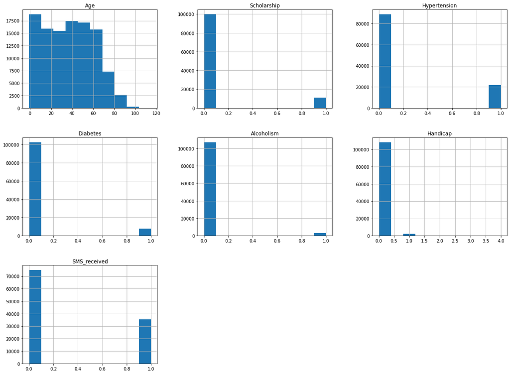

```python
# Display data in histogram format.
df.hist(figsize=(20, 15));
```

### data cleaning (fix data type)

> Here we will modify some data properties, and correct errors as follows:-

> Change the name of the column "No-show" to "No_show" because it is not suitable for correct processing.

> Show the most important factors to check (PatientId, AppointmentID, ScheduledDay, AppointmentDay).

## Exploratory Data Analysis

###### overview in tha data :

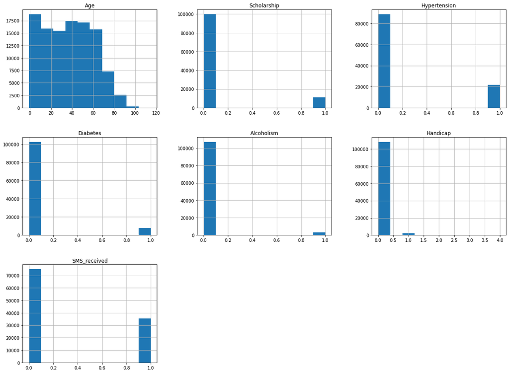

```python
# Display data in histogram format.
df.hist(figsize = (20,15));
```

```python
# function to making graphs and statistics.
def BarTographs(df, xVar, fig):

    g = df.groupby("No_show")[xVar].value_counts(normalize=True).unstack("No_show").plot.bar(rot=0, figsize=fig)

    for p in g.patches:
        g.annotate(f'{str(round(p.get_height()*100, 2))}%', (p.get_x()+ 0.5*(p.get_width()), p.get_height()),
            ha="center", va="bottom",
            fontsize=14, weight="bold") # Display values on a graph.

    plt.title(f'Percentage Show/No Show for {xVar}'.title(), fontsize=14, weight="bold") # title.
    plt.xlabel(xVar.title())  # x title.
    plt.ylabel("percantage")  # y title.
```

## R Q 1 : How many showed vs not_showed and what relation ??

```
ratio of showed:  79.8067440534892
```

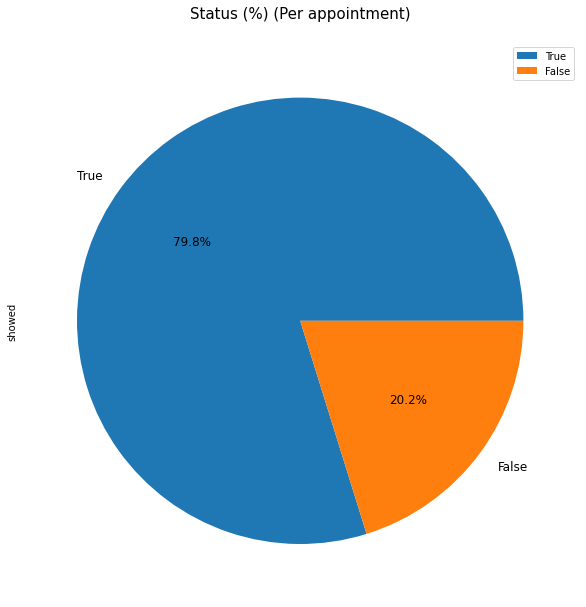

```python
all_pat = df['showed'].value_counts()
print('ratio of showed: ', all_pat[1]/ all_pat.sum() * 100)
pie = all_pat.plot.pie(figsize = (10,12), autopct='%1.1f%%', fontsize = 12);
pie.set_title("Status" + ' (%) (Per appointment)\n', fontsize = 15);
plt.legend();
```

## R Q 2 : Does 'Gender' affect attendance?

```python
# Display attendance and no-show numbers by gender.
df.groupby("No_show")["Gender"].value_counts()
```

```
No_show  Gender
0        F         14594
         M          7725
1        F         57246
         M         30962
Name: Gender, dtype: int64
```

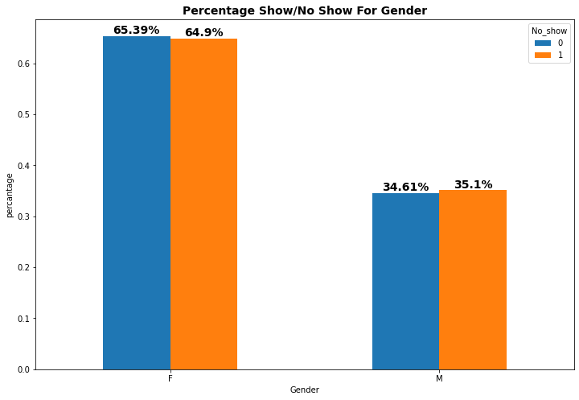

```python
# Display a graph of attendance and no-show ratios by gender.(df,"Gender", (12, 8))
BarTographs(df,"Gender", (12, 8))
```

From the above information, it is clear that "Gender" not has an obvious effect on attendance .

### R Q 3: Does the scholarship affect attendance?

```python
# Display attendance and no-show numbers by Scholarship.
df.groupby("No_show")["Scholarship"].value_counts()
```

```
No_show  Scholarship
0        0              19741
         1               2578
1        0              79925
         1               8283
Name: Scholarship, dtype: int64
```

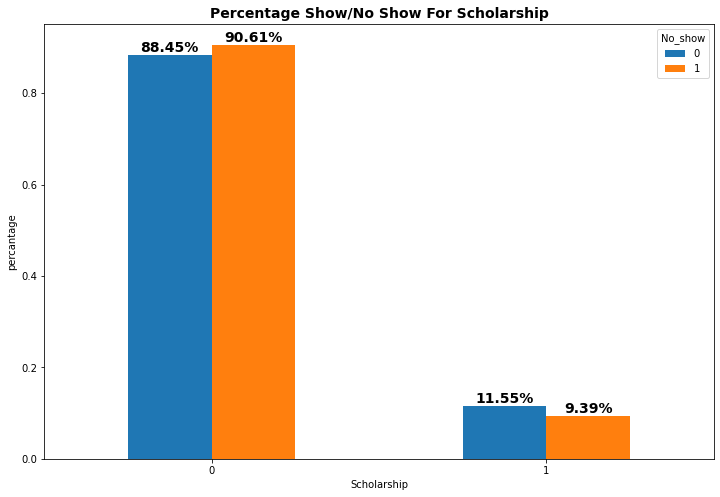

```python
# Display a graph of attendance and no-show ratios by Scholarship.
BarTographs(df,"Scholarship", (12, 8))
```

From the above information, it is clear that "Scholarship" has an obvious effect on attendance .

### R Q 4 : Does 'Diabetes' affect attendance?

```python
# Display attendance and no-show numbers by Diabetes.
df.groupby("No_show")["Diabetes"].value_counts()
```

```
No_show  Diabetes
0        0           20889
         1            1430
1        0           81695
         1            6513
Name: Diabetes, dtype: int64
```

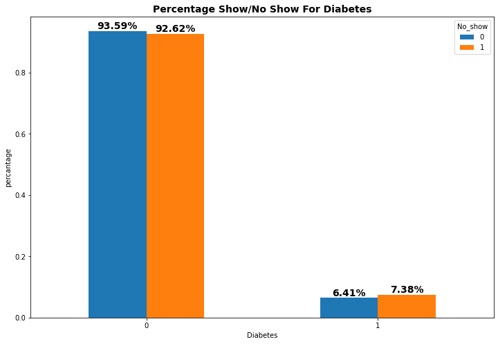

```python
# Display a graph of attendance and no-show ratios by Diabetes.
BarTographs(df,"Diabetes", (12,8))
```

From the above information, it is clear that "Diabetes" not has an obvious effect on attendance .

### R Q 5: Does "Hypertension" affect attendance?

```python
# Display attendance and no-show numbers by Hipertension.
df.groupby("No_show")["Hypertension"].value_counts()
```

```
No_show  Hypertension
0        0               18547
         1                3772
1        0               70179
         1               18029
Name: Hypertension, dtype: int64
```

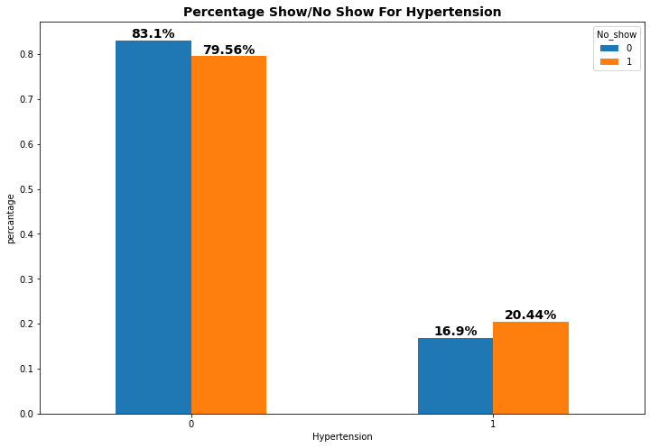

```python
# Display a graph of attendance and no-show ratios by Hipertension.
BarTographs(df,"Hypertension", (12, 8))
```

From the above information, it is clear that "Hipertension" has an obvious effect on attendance .

### R Q 6 : Does 'alcoholism' affect attendance?

```python
# Display attendance and no-show numbers by Alcoholism.
df.groupby("No_show")["Alcoholism"].value_counts()
```

```
No_show  Alcoholism
0        0             21642
         1               677
1        0             85525
         1              2683
Name: Alcoholism, dtype: int64
```

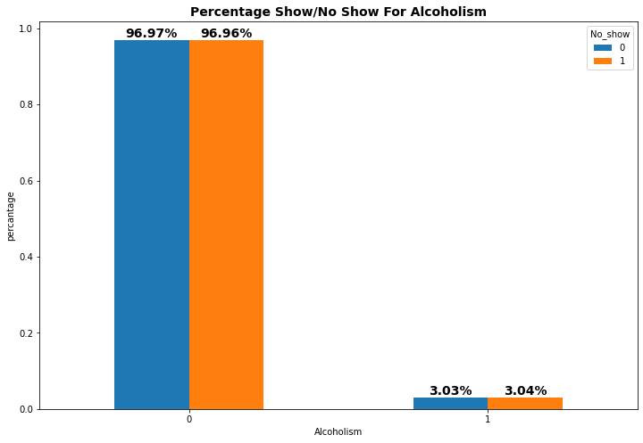

```python
# Display a graph of attendance and no-show ratios by Alcoholism.
BarTographs(df,"Alcoholism",(12, 8))
```

From the above information, it is clear that "Alcoholism" not has an obvious effect on attendance .

### RQ 7 : Does 'age' affect attendance?

```python
# Display attendance and no-show numbers by Age.
df.groupby("No_show")["Age"].value_counts()
```

```
No_show  Age
0         0      639
          1      415
          17     396
          19     394
          30     369
                ...
1         100      4
          102      2
          115      2
         -1        1
          99       1
Name: Age, Length: 204, dtype: int64
```

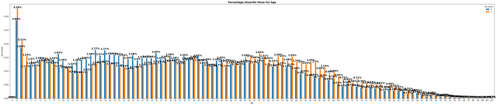

```python
# Display a graph of attendance and no-show ratios by Age.
BarTographs(df,"Age",(50,10))
```

From the above information, it is clear that "age" not has an obvious effect on attendance .

### R Q 8 : Is there an anomaly in age, and what is the average age of the patient?

```python
# Display statistical information about age data according to attendance and no-show.
df.groupby("No_show")["Age"].describe()
```

| No_show | count | mean | std | min | 25% | 50% | 75% | max |
| --- | --- | --- | --- | --- | --- | --- | --- | --- |
| 0 | 22319.0 | 34.317667 | 21.965941 | 0.0 | 16.0 | 33.0 | 51.0 | 115.0 |
| 1 | 88208.0 | 37.790064 | 23.338878 | -1.0 | 18.0 | 38.0 | 56.0 | 115.0 |

[figure not shown]

```python
# Display a graph showing statistical information on age data.
df["Age"].plot.box(rot=0, figsize=(10, 9));
plt.title("The market share of the hospital".title(), fontsize=14, weight="bold");
```

#### It is clear from the above information that the average age of patients is (37), and that there are anomalous values for age (115).

### R Q 9 : Which hospitals have the highest attendance rate and which are the least?

```python
# Display the number of clients in each hospital separately.
df["Neighbourhood"].value_counts()
```

```
JARDIM CAMBURI                 7717
MARIA ORTIZ                    5805
RESISTÊNCIA                    4431
JARDIM DA PENHA                3877
ITARARÉ                        3514
                               ...
ILHA DO BOI                      35
ILHA DO FRADE                    10
AEROPORTO                         8
ILHAS OCEÂNICAS DE TRINDADE       2
PARQUE INDUSTRIAL                 1
Name: Neighbourhood, Length: 81, dtype: int64
```

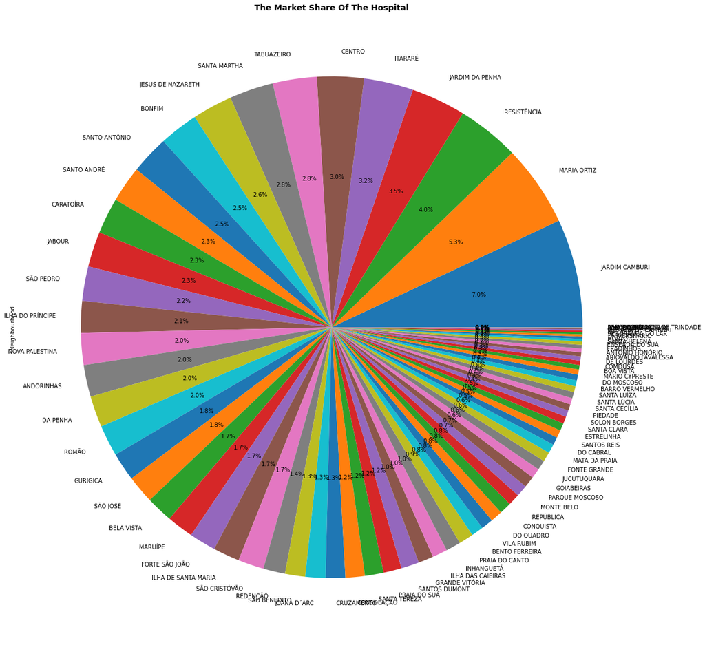

```python
# Function to display a graph of the percentage of each hospital in the market.
dg = df["Neighbourhood"].value_counts(normalize=True)*100
dg.plot.pie(rot=0, figsize=(30, 20), autopct='%1.1f%%');

plt.title("The market share of the hospital".title(), fontsize=14, weight="bold"); # title.
```

### R Q 10 : Does “neighborhood” affect attendance?

```python
# Display the attendance and no-show numbers in each hospital separately.
df.groupby("Neighbourhood")["No_show"].value_counts().unstack("No_show")
```

| No_show Neighbourhood | 0 | 1 |
| --- | --- | --- |
| AEROPORTO | 1.0 | 7.0 |
| ANDORINHAS | 521.0 | 1741.0 |
| ANTÔNIO HONÓRIO | 50.0 | 221.0 |
| ARIOVALDO FAVALESSA | 62.0 | 220.0 |
| BARRO VERMELHO | 91.0 | 332.0 |
| ... | ... | ... |
| SÃO JOSÉ | 428.0 | 1549.0 |
| SÃO PEDRO | 515.0 | 1933.0 |
| TABUAZEIRO | 573.0 | 2559.0 |
| UNIVERSITÁRIO | 32.0 | 120.0 |
| VILA RUBIM | 141.0 | 710.0 |

81 rows × 2 columns

```python
# Function to display a graph of attendance and no-show rates in each hospital separately.
dgd = df.groupby("Neighbourhood")["No_show"].value_counts(normalize=True).unstack("No_show").plot.bar(rot=0, figsize=(200, 70))

for p in dgd.patches:
    dgd.annotate(f'{str(round(p.get_height()*100, 2))}%', (p.get_x()+ 0.5*(p.get_width()), p.get_height()),
               ha="center", va="bottom",
               fontsize=14, weight="bold");  # Display values on a graph.

plt.title("Attendance rates from booking dates and no-show".title(), fontsize=14, weight="bold");   # title
plt.xlabel("Neighbourhood");  # x title
plt.ylabel("percantage");    # y title
```

[figure not shown]

From the above information, it is clear that "Neighbourhood" has an obvious effect on attendance .

### R Q 11 : Does 'Handicap' affect attendance?

```python
# Display attendance and no-show numbers by Handcap.
df.groupby("No_show")["Handicap"].value_counts().unstack()
```

| Handicap No_show | 0 | 1 | 2 | 3 | 4 |
| --- | --- | --- | --- | --- | --- |
| 0 | 21912 | 366 | 37 | 3 | 1 |
| 1 | 86374 | 1676 | 146 | 10 | 2 |

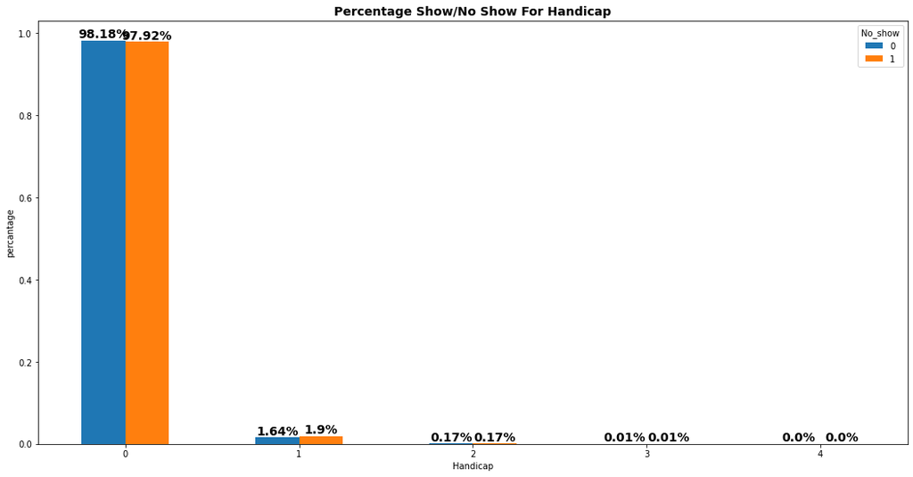

```python
# Display a graph of attendance and no-show ratios by Handcap.
BarTographs(df,"Handicap", (18, 9))
```

From the above information, it is clear that "Handicap"not has an obvious effect on attendance .

### R Q 12 : Does 'SMS_received' affect attendance?

```python
# Display attendance and no-show numbers by SMS_received.
df.groupby("No_show")["SMS_received"].value_counts().unstack()
```

| SMS_received No_show | 0 | 1 |
| --- | --- | --- |
| 0 | 12535 | 9784 |
| 1 | 62510 | 25698 |

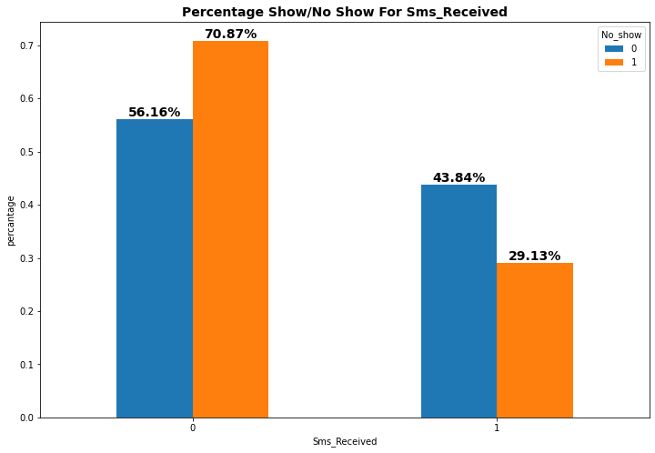

```python
# Display a graph of attendance and no-show ratios by SMS_received.
BarTographs(df,"SMS_received",(12, 8))
```

There is a relationship here, but it cannot be properly interpreted, as the number of attendees who were not sent messages is much larger than the attendees to whom messages were sent.

## Conclusions

### Limitations :-

> > Missing featuares :-
> > - 1- that can be useful to make sure more than the most affected feature appears at the appointment, such as whether or not the patient is working, or whether or not the patient has a recurring medical problem.
> > - 2- We have some illogical data such as patients 0 or younger
> > - Lack of sufficient information about the hospital, such as reputation, advertising budget, quality of service and other factors that may influence patients' decision to continue dealing with this hospital.
> > - Not mentioning the patient's social level, even if it was one of the factors affecting frequency to the doctor.
> > - The sample size of the data is good, but it is not proportional to the size of the community and is not sufficient to extract high quality information.

```python
from subprocess import call
call(['python', '-m', 'nbconvert', 'Investigate_a_Dataset.ipynb'])
```